# Predictive Modeling of Heart Diseases

Statistical Learning - Midterm

Michelle Hajduk

2024-02-27

# Introduction

Cardiovascular diseases, claiming 17.9 million lives annually, including heart disease, remain a leading cause of morbidity and mortality globally. This group includes coronary heart disease, cerebrovascular disease, and rheumatic heart disease, with over 80% of deaths attributed to heart attacks and strokes, one-third occurring prematurely in those under 70. Preventing premature deaths relies on identifying high-risk individuals and ensuring timely treatment through counseling and medications (Organization 2021).

In this study, we aim to develop a predictive model for heart disease based on a dataset containing key clinical features. Therefore we use the [Heart Failure Prediciton Dataset](https://www.kaggle.com/fedesoriano/heart-failure-prediction) from kaggle with 918 observations that occured in Cleveland, Hungarian, Switzerland, Long Beach VA, and Stalog. This comprehensive dataset is the result of combining 5 independent heart datasets, comprising a total of 11 common features.

The dataset heart.csv includes the following 12 variables:

- Age: Age of the patient in years,
- Sex: Gender of the patient (M: Male, F: Female),
- ChestPainType: Type of chest pain (TA: Typical Angina, ATA: Atypical Angina, NAP: Non-Anginal Pain, ASY: Asymptomatic),
- RestingBP: Resting blood pressure in mm Hg,
- Cholesterol: Serum cholesterol in mm/dl,
- FastingBS: Fasting blood sugar (1: if FastingBS > 120 mg/dl, 0: otherwise),
- RestingECG: Resting electrocardiogram results (Normal: Normal, ST: having ST-T wave abnormality, LVH: showing probable or definite left ventricular hypertrophy by Estes criteria),
- MaxHR: Maximum heart rate achieved,
- ExerciseAngina: Exercise-induced angina (Y: Yes, N: No),
- Oldpeak: Oldpeak = ST (Numeric value measured in depression),
- ST_Slope: The slope of the peak exercise ST segment (Up: upsloping, Flat: flat, Down: downsloping),
- HeartDisease: Output class (0: No Heart Disease, 1: Heart Disease).

The former eleven variables capture diverse aspects relevant to the latter heart disease variable, which describes the response variable.

# Exploratory Data Analysis (EDA) and Pre-Processing

Before building models, a comprehensive exploration of the data is essential to gain insights into the response variable. Additionally, we must preprocess our training data to establish a robust foundation for model creation.

The first step contains splitting the data into a train and a test dataset. It is crucial to split the data before delving into its details to ensure a realistic representation of the situation, so we also have to prevent inadvertent leakage of testing data during preprocessing and model building. We use the `createDataPartition()` function to partition the data into distinct sets for training (`train_data`) and testing (`test_data`). The data split ratio is set at 80%, allocating 80% to the training set and the remaining 20% to the test set. To ensure reproducibility, we specify a seed, allowing for the consistent reproduction of the same random samples across analyses.

```r
# Split between training and testing sets with createDataPartition() from the caret library
set.seed(999) #Set seed for reproducibility
spl = createDataPartition(data$HeartDisease, p = 0.8, list = FALSE)  # 80% for training

# Create train_data and test_data based on spl
train_data = data[spl,]
test_data = data[-spl,]
```

To ensure a comparable distribution of heart disease across our datasets, we performe an analysis of the prevalence of heart disease in each dataset. The comparison reveals that the distribution of heart disease is reasonably consistent across the whole dataset, training set, and testing set. The distribution variations are within an acceptable range. This balance is crucial for the generalizability of our models, as it helps prevent biases that may arise from imbalances in class distribution.

```r
# Check the distribution of heart disease
table(data$HeartDisease)/length(data$HeartDisease)
```

```
        0         1
0.4466231 0.5533769
```

```r
table(train_data$HeartDisease)/length(train_data$HeartDisease)
```

```
        0         1
0.4517007 0.5482993
```

```r
table(test_data$HeartDisease)/length(test_data$HeartDisease)
```

```
        0         1
0.4262295 0.5737705
```

Now, let us quickly overview the train dataset. It consists of 735 observations and 12 variables, including our key response variable, “HeartDisease”. These variables comprise six integers as well as one numeric capturing numerical aspects and five characters providing information on gender, chest pain type, electrocardiogram status, and more.

```r
# Visualize train dataset
str(train_data)
```

```
'data.frame':   735 obs. of  12 variables:
 $ Age           : int  40 49 48 54 39 45 37 48 37 39 ...
 $ Sex           : chr  "M" "F" "F" "M" ...
 $ ChestPainType : chr  "ATA" "NAP" "ASY" "NAP" ...
 $ RestingBP     : int  140 160 138 150 120 130 140 120 130 120 ...
 $ Cholesterol   : int  289 180 214 195 339 237 207 284 211 204 ...
 $ FastingBS     : int  0 0 0 0 0 0 0 0 0 0 ...
 $ RestingECG    : chr  "Normal" "Normal" "Normal" "Normal" ...
 $ MaxHR         : int  172 156 108 122 170 170 130 120 142 145 ...
 $ ExerciseAngina: chr  "N" "N" "Y" "N" ...
 $ Oldpeak       : num  0 1 1.5 0 0 0 1.5 0 0 0 ...
 $ ST_Slope      : chr  "Up" "Flat" "Flat" "Up" ...
 $ HeartDisease  : int  0 1 1 0 0 0 1 0 0 0 ...
```

**Handling Missing Values**

In the next step, we conducted an analysis to identify missing values within the train dataset. Ensuring the absence of missing data is crucial for maintaining data quality, enhancing model performance, and ensuring accurate and unbiased interpretation of results. The results indicate that there are no missing values present in any of the variables. So no data processing is required at this stage.

```r
# Calculate number of NA values per column
colSums(sapply(train_data, is.na))
```

```
           Age            Sex  ChestPainType      RestingBP    Cholesterol
             0              0              0              0              0
     FastingBS     RestingECG          MaxHR ExerciseAngina        Oldpeak
             0              0              0              0              0
      ST_Slope   HeartDisease
             0              0
```

**Factorizing**

Further on, we need to convert the character variables to factors. This is done by using the `mutate_if` function, ensuring that categorical variables are appropriately formatted. Additionally, the categorical variable “FastingBS” underwent conversion into a factor. However, due to its initial numerical nature, this conversion had to be handled separately. Furthermore, for the successful prediction of the Heart Disease class in subsequent modeling, it is crucial to convert this response variable into a factor with explicit levels set as “No Heart Disease” and “Heart Disease”. As we can observe in the below string output of `train_data`, the variables have been successfully converted. The dataset now comprises 5 numerical variables (Age, RestingBP, Cholesterol, MaxHR, and OldPeak) alongside 7 categorical variables (Sex, ChestPainType, FastingBS, RestingECG, ExerciseAngina, ST_Slope, and the target variable, HeartDisease).

```r
# Convert character variables to factors using mutate_if function
train_data <- train_data %>% mutate_if(~is.character(.), ~as.factor(.))

# Convert the variable 'FastingBS' to a factor
train_data$FastingBS <- as.factor(train_data$FastingBS)

# Convert the response variable 'HeartDisease' to a factor
train_data$HeartDisease <- as.factor(train_data$HeartDisease)

# Set explicit levels for the 'HeartDisease' factor
levels(train_data$HeartDisease) <- c("No Heart Disease", "Heart Disease")

# Display the structure of the transformed training dataset
str(train_data)
```

```
'data.frame':   735 obs. of  12 variables:
 $ Age           : int  40 49 48 54 39 45 37 48 37 39 ...
 $ Sex           : Factor w/ 2 levels "F","M": 2 1 1 2 2 1 2 1 1 2 ...
 $ ChestPainType : Factor w/ 4 levels "ASY","ATA","NAP",..: 2 3 1 3 3 2 1 2 3 2 ...
 $ RestingBP     : int  140 160 138 150 120 130 140 120 130 120 ...
 $ Cholesterol   : int  289 180 214 195 339 237 207 284 211 204 ...
 $ FastingBS     : Factor w/ 2 levels "0","1": 1 1 1 1 1 1 1 1 1 1 ...
 $ RestingECG    : Factor w/ 3 levels "LVH","Normal",..: 2 2 2 2 2 2 2 2 2 2 ...
 $ MaxHR         : int  172 156 108 122 170 170 130 120 142 145 ...
 $ ExerciseAngina: Factor w/ 2 levels "N","Y": 1 1 2 1 1 1 2 1 1 1 ...
 $ Oldpeak       : num  0 1 1.5 0 0 0 1.5 0 0 0 ...
 $ ST_Slope      : Factor w/ 3 levels "Down","Flat",..: 3 2 2 3 3 3 2 3 3 3 ...
 $ HeartDisease  : Factor w/ 2 levels "No Heart Disease",..: 1 2 2 1 1 1 2 1 1 1 ...
```

**Visualization**

*Categorical variables*

First, we want to explore the following categorical variables within the dataset: “Sex”, “ChestPainType”, “FastingBS”, “RestingECG”, “ExerciseAngina”, and “ST_Slope”. We do so by creating a bar plot for each variable to assess the distribution of each categories. By that we can identify potential predictors with unique categories or those leaning towards a single category, which may indicate limited predictive value.

The bar plots reveal a subtle pattern across several categorical variables, where one level appears to have a lower distribution compared to others. Notably, the variable “Sex” exhibits the most pronounced pattern, with the bar representing males approximately four times higher than that representing females. While this slight imbalance suggests a difference in distribution, especially in the case of “Sex”, it is important to note that this does not necessarily diminish the importance of the variables. Further consideration and analysis may be warranted to understand the potential impact on modeling outcomes.

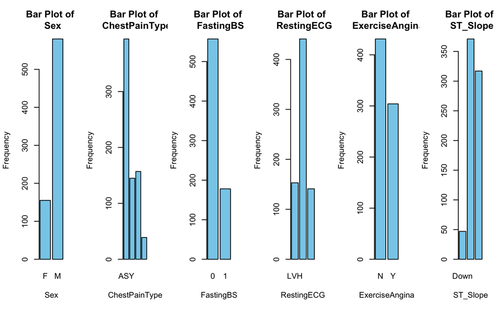

```r
# Define categorical variables
categorical_variables <- c("Sex", "ChestPainType", "FastingBS", "RestingECG", "ExerciseAngina", "ST_Slope")

# Set up the plotting layout
par(mfrow = c(1, 6))

# Loop through each categorical variable for barplot creation
for (variable in categorical_variables) {
  # Create a bar plot
  barplot(table(train_data[[variable]]),
          main = paste("Bar Plot of \n", variable),
          xlab = variable, ylab = "Frequency", col = "skyblue")
}
```

*Numeric Variables*

Now, we want to analyse the distribution of the numerical variables. The goal is to gain insights into the spread and patterns within variables such as “Age”, “RestingBP”, “Cholesterol”, “MaxHR”, and “Oldpeak”. Therefore we will use the `ggpairs()` function from the GGally library. This function generates a grid of scatterplots, density plots, and correlation coefficients, offering a comprehensive visualization of the pairwise interactions.

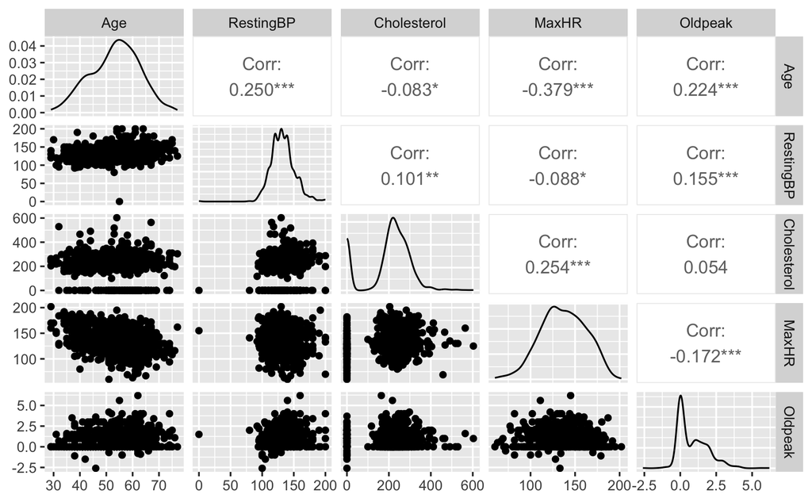

```r
# Define numerical variables
numeric_variables <- c("Age", "RestingBP", "Cholesterol","MaxHR", "Oldpeak")

# Subset the dataset to include only numeric variables
numeric_data <- train_data[, numeric_variables]

# Create a ggpairs plot from library GGally
ggpairs(numeric_data)
```

The ggpairs plot shows that the numeric variables exhibit no strong correlations. The correlation coefficients range between -0.379 and 0.254, suggesting mainly weak to moderate linear relationships among these variables. Some outliers can be detected by the scatter plots. In dealing with outliers, the typical approaches involve imputation or omission strategies. However, in the context of medical data, it becomes imperative to consider the unique nature of the information. Medical outliers may signify valid and abnormal health conditions demanding attention.

For instance, in cholesterol levels, where the normal value is less than 120 mm/dl, any value exceeding this threshold signals high cholesterol and warrants attention (Clinic 2022). Similarly, variations in resting blood pressure, with a normal range of 120/80, are indicative of potential high or low blood pressure (Association 2023). Moreover, the normal range for MaxHR is contingent on age. Treating the range of MaxHR as outliers would be inappropriate, given the age variability spanning from 28 to 77 (Disease Control and Prevention 2022). Lastly, interpreting Old Peak, a term denoting ST Depression, is pivotal. A baseline of 0 signifies a healthy heart, while any deviation from this baseline indicates ST depression—a critical sign that the cardiac muscle may not be receiving adequate oxygen, among other factors (Kharel et al. 2020). Therefore, a nuanced understanding of medical data is essential to avoid misinterpretation and ensure the preservation of vital health insights.

Looking at the density plots for each variable, it becomes evident that the variable “Cholesterol” exhibits a high density at low values. To delve deeper into this, we scrutinize the low values through the following histogram and density plot.

```r
# Plot distribution of Cholesterol
hist(train_data[["Cholesterol"]],
       col = "lightblue",
       main = "Distribution Plot of Cholesterol",
       xlab = "Cholesterol", ylab = "Frequency",
       probability = TRUE)

# Add a kernel density estimate (KDE)
lines(density(train_data[["Cholesterol"]]), col = "blue", lwd = 2)
```

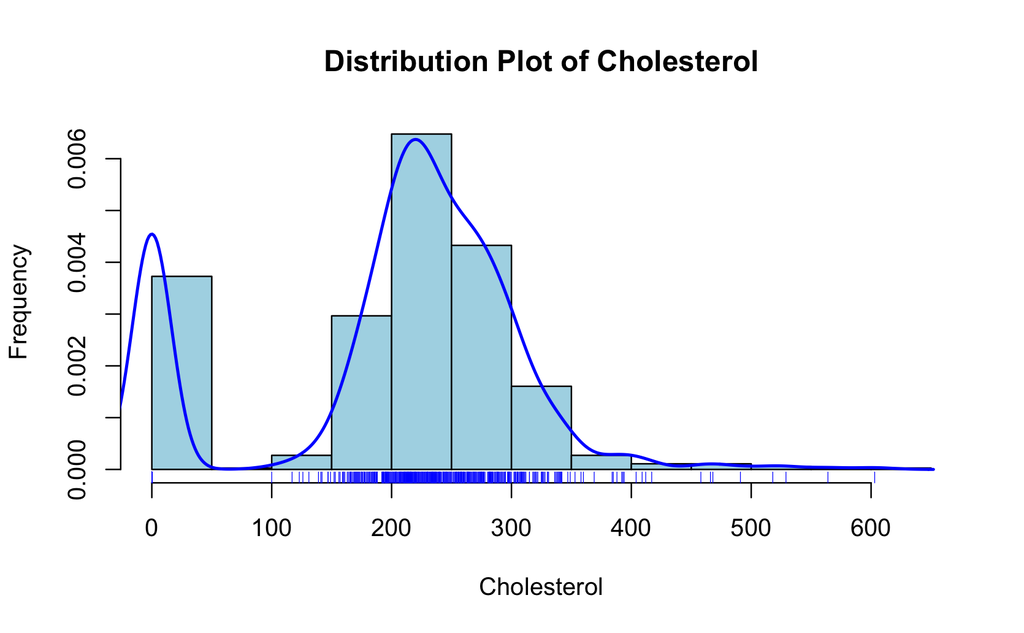

```r
# Add a rug ploz
rug(train_data[["Cholesterol"]], col = "blue")
```

Upon closer inspection, it becomes apparent that some observations possess a value of 0, a biologically implausible scenario. This discrepancy could be attributed to accidental recording of 0 instead of a missing value (NA). Consequently, we address this issue by treating these values and opting to impute them with the datasets median value, calculated to be 222.

```r
# Calculate the median value
median_value <- median(train_data$Cholesterol, na.rm = TRUE)

# Impute values with the median for instances where Cholesterol equals 0
train_data$Cholesterol <- ifelse(train_data$Cholesterol == 0, median(train_data$Cholesterol), train_data$Cholesterol)
```

**Skewness**

Upon inspecting the ggpairs density plot, it shows that there is skewness present in the distribution of each variable. To enhance the normality of the data and mitigate skewness, it is essential to assess the degree of skewness in each variable before implementing corrective measures.

```r
# Calculate skewness of numerical variables
skewness_values <- sapply(train_data[, sapply(train_data, is.numeric)], skewness)
print(skewness_values)
```

```
        Age   RestingBP Cholesterol       MaxHR     Oldpeak
-0.18229148  0.06240905  1.80804393 -0.13831994  1.01430824
```

The result shows high positive skewness for Cholesterol and Oldpeak. To address this, we opt for a logarithmic transformation. For Cholesterol, a straightforward log transformation is applied after adding 1 to avoid the logarithm of zero. However, due to the presence of negative values in Oldpeak, a more nuanced approach involving scaling and shifting is required. This technique involves adjusting the data by shifting its values to make them positive and then applying a logarithmic transformation to reduce skewness.

```r
# Apply logarithmic transformation to Cholesterol
train_data$Cholesterol <- log(train_data$Cholesterol + 1)  # Adding 1 to avoid log(0)

# Shift and scale transformation for Oldpeak
shift_constant <- abs(min(train_data$Oldpeak)) + 1  # Adding 1 for additional positivity
train_data$Oldpeak <- sign(train_data$Oldpeak) * log(abs(train_data$Oldpeak) + shift_constant)
```

Upon re-evaluating the skewness values, it is apparent that these transformations have successfully reduced the skewness in both variables.

```r
skewness_values_after <- sapply(train_data[, sapply(train_data, is.numeric)], skewness)
print(skewness_values_after)
```

```
        Age   RestingBP Cholesterol       MaxHR     Oldpeak
-0.18229148  0.06240905  0.47148113 -0.13831994 -0.47241235
```

**Relationships in context with Heart Disease**

In this step, we aim to enhance our understanding of the “HeartDisease” variable. To achieve this, we firstly create a scatterplot matrix that visually examines relationships among key variables. The color scheme distinguishes Heart Disease status, where blue represents “No Heart Disease” and orange represents “Heart Disease”. Notably, there is no discernible pattern for the variables “Age”, “RestingBP”, and “Cholesterol” concerning heart disease. However, an intriguing observation emerges for “MaxHR”, indicating that a lower maximal heart rate tend to correlate with heart disease, while higher values lean towards the absence of heart disease. This insight suggests a potential influential role of “MaxHR” in determining the presence or absence of heart disease.

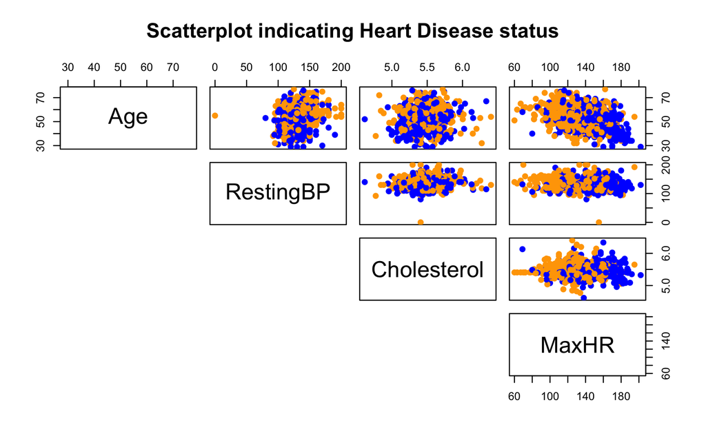

```r
# Creating a scatterplot matrix with colors indicating Heart Disease status
colors_heart <- c("blue", "orange")[train_data$HeartDisease]

# Scatterplot matrix for selected variables
pairs(train_data[, c("Age", "RestingBP", "Cholesterol", "MaxHR")],
      main = "Scatterplot indicating Heart Disease status", pch = 19, col = colors_heart, lower.panel = NULL)
```

Upon inspecting the scatterplot matrix, a notable outlier is detected in the “RestingBP” variable with a unique value of 0. As this appears to be an anomalous observation and could be a data entry error, the missing or erroneous value is imputed with the median resting blood pressure.

```r
# Calculate the median resting blood pressure
median_restingBP <- median(train_data$RestingBP, na.rm = TRUE)

# Impute missing value
train_data$RestingBP[train_data$RestingBP == 0] <- median_restingBP
```

Now, we will analyze the correlation between the response variable “HeartDisease” and the numerical variables. This involves creating a correlation matrix and presenting the results through a corrplot and a sorted bar plot.

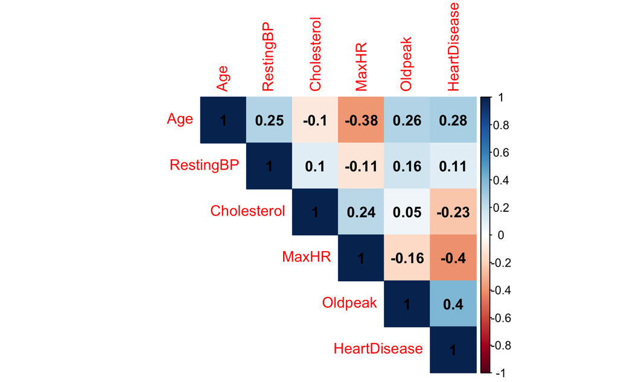

```r
# Specify numeric variables including 'HeartDisease'
numeric_variables_incl_hd <- c("Age", "RestingBP", "Cholesterol", "MaxHR", "Oldpeak", "HeartDisease")

subset_data <- data[, numeric_variables_incl_hd, drop = FALSE]

# Calculate the correlation matrix with 'HeartDisease' temporarily converted to numeric
correlation_matrix <- subset_data %>%
  transmute(across(everything(), as.numeric)) %>%
  cor()

# Print the correlation matrix
corrplot(correlation_matrix, method = "color", type = "upper", addCoef.col = "black")
```

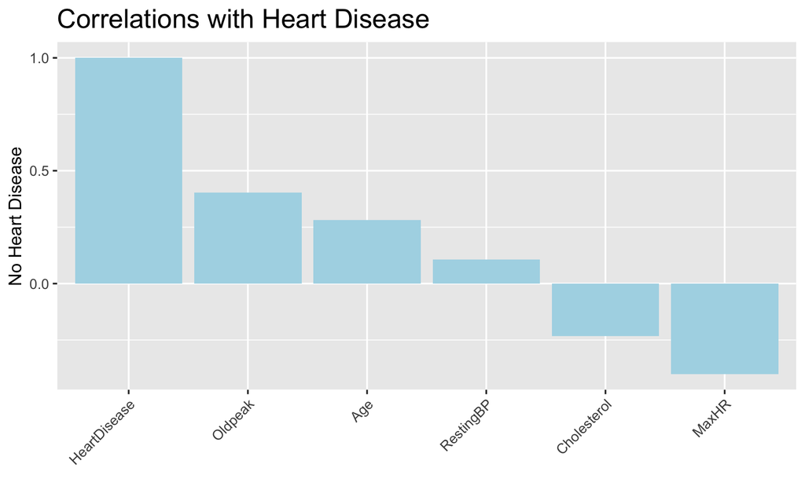

```r
corr_heart_disease <- sort(correlation_matrix[,"HeartDisease"], decreasing = TRUE)

corr <- data.frame(corr_heart_disease)

# Plotting correlations with the target variable
ggplot(corr, aes(x = row.names(corr), y = corr_heart_disease)) +
  geom_bar(stat = "identity", fill = "lightblue") +
  scale_x_discrete(limits = row.names(corr)) +
  labs(x = "", y = train_data$HeartDisease, title = "Correlations with Heart Disease") +
  theme(plot.title = element_text(hjust = 0, size = rel(1.5)),
        axis.text.x = element_text(angle = 45, hjust = 1))
```

From the correlation matrix, it is evident that “Oldpeak” exhibits the highest positive correlation (+0.4), while “MaxHR” demonstrates the most substantial negative correlation (-0.4) with “HeartDisease”. Although these correlations are relatively moderate, they signify that “Oldpeak” and “MaxHR” emerge as the most influential predictors among the numerical variables. The variables “Age”, “RestingBP”, “Cholesterol”, and “MaxHR” do not exhibit strong correlations with “HeartDisease”. However, a more in-depth examination of their relationships and significance will be conducted during the subsequent modeling phase.

Now, we employ the `ggplot` package to investigate the association between various levels of each categorical variable and the response variable Heart Disease. Through this analysis, we generate informative bar plots that visually illustrate the distribution of Heart Disease across different categorical variable levels.

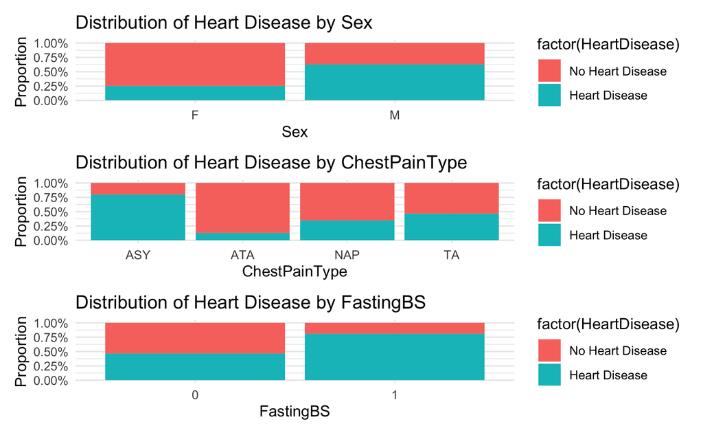

```r
# Create an empty list to store the plots
plots_list <- list()

# Iterate through the variables and create plots
for (variable in categorical_variables) {
  plot <- ggplot(train_data, aes(x = !!sym(variable), fill = factor(HeartDisease))) +
    geom_bar(position = 'fill') +
    labs(title = paste('Distribution of Heart Disease by', variable),
         x = variable,
         y = 'Proportion') +
    scale_y_continuous(labels = scales::percent_format(scale = 1)) +
    theme_minimal()

  # Add the plot to the list
  plots_list[[variable]] <- plot
}
# Using patchwork
plots_list[[1]] / plots_list[[2]] / plots_list[[3]]
```

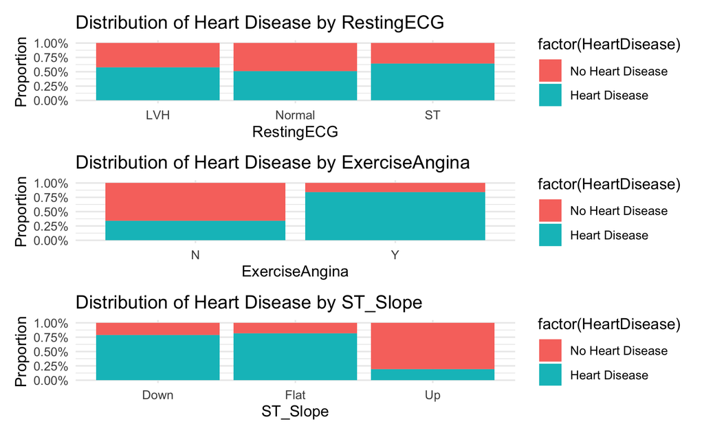

```r
plots_list[[4]] / plots_list[[5]] / plots_list[[6]]
```

**Scaling numeric variables**

In this phase, we concentrate on standardizing the numerical variables within the dataset to ensure uniformity in scales, preventing the dominance of variables with larger magnitudes and facilitating fair contributions from each variable during modeling. To do this, we use the `scale()` function to standardize the numeric features by subtracting the mean and dividing by the standard deviation. This ensures that all numerical variables have a mean of 0 and a standard deviation of 1, creating a standardized distribution for each feature. The standardized numerical features are stored in the `scaled_numeric_data` dataframe. We then replace the original numerical features in the `train_data` dataframe with their scaled counterparts using the `numeric_variables` subset. Finally, we inspect the first few rows of the dataset, allowing us to verify that the scaling process has been successfully applied.

```r
# Scale the numerical features
scaled_numeric_data <- as.data.frame(scale(numeric_data))

# Replace the original numerical features with the scaled ones in the original dataframe
train_data[numeric_variables] <- scaled_numeric_data

# Check the first few rows of the updated dataframe
head(train_data)
```

|  | Age | Sex | ChestPainType | RestingBP | Cholesterol | FastingBS | RestingECG | MaxHR | ExerciseAngina | Oldpeak | ST_Slope | HeartDisease |
| --- | --- | --- | --- | --- | --- | --- | --- | --- | --- | --- | --- | --- |
| 1 | -1.44102068 | M | ATA | 0.4010293 | 0.8128866 | 0 | Normal | 1.4007271 | N | -0.8346364 | Up | No Heart Disease |
| 2 | -0.47149751 | F | NAP | 1.4680213 | -0.1796215 | 0 | Normal | 0.7635650 | N | 0.1250910 | Flat | Heart Disease |
| 4 | -0.57922231 | F | ASY | 0.2943301 | 0.1299682 | 0 | Normal | -1.1479211 | Y | 0.6049547 | Flat | Heart Disease |
| 5 | 0.06712647 | M | NAP | 0.9345253 | -0.0430378 | 0 | Normal | -0.5904043 | N | -0.8346364 | Up | No Heart Disease |
| 6 | -1.54874547 | M | NAP | -0.6659627 | 1.2681655 | 0 | Normal | 1.3210818 | N | -0.8346364 | Up | No Heart Disease |
| 7 | -0.90239670 | F | ATA | -0.1324667 | 0.3393965 | 0 | Normal | 1.3210818 | N | -0.8346364 | Up | No Heart Disease |

**Naive Prediction for Heart Disease**

In the final step of the EDA and Preprocessing, we visually explore the frequency of heart disease in our dataset using a bar plot.

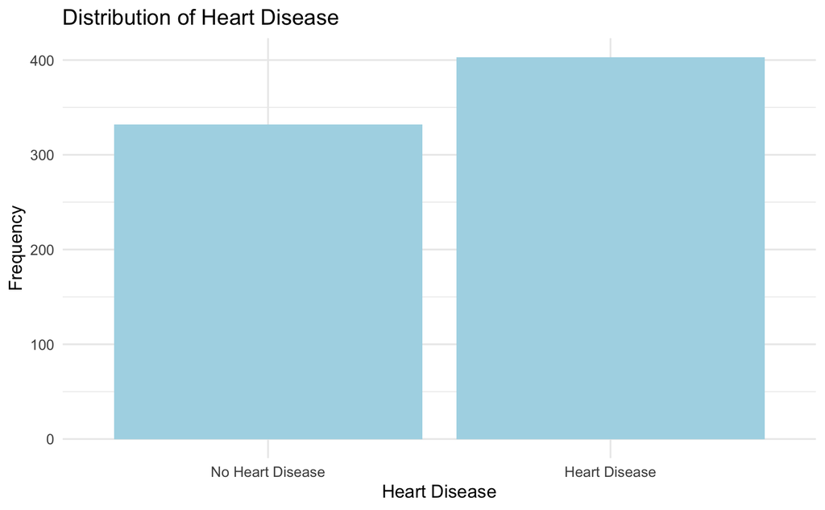

```r
# Assuming 'heart' is your dataframe
ggplot(train_data, aes(x = factor(HeartDisease))) +
  geom_bar(fill = 'lightblue') +
  labs(title = 'Distribution of Heart Disease',
       x = 'Heart Disease',
       y = 'Frequency') +
  theme_minimal()
```

Simultaneously, we make a simple prediction by guessing the most common outcome for heart disease. The result of this naive prediction reveals that the prevalence of individuals having heart disease in the dataset is slightly higher than those without. This common outcome helps us for subsequent model evaluations. It serves as a benchmark to measure the performance of more sophisticated models. By comparing advanced models with this basic guess, we assess whether our models offer valuable insights beyond a simple prediction.

```r
# Naive prediction using the mode of Heart Disease
table_heart_disease <- table(train_data$HeartDisease)
naive_prediction <- as.character(names(table_heart_disease)[which.max(table_heart_disease)])
naive_prediction
```

```
[1] "Heart Disease"
```

# Classification Modeling

This section contains building, evaluating and comparing different models. However, before proceeding with model development, it is crucial to factorize the categorical variables as well as the variables “FastingBS” and “HeartDisease” from the `test_data` dataset for accurate predictions. It ensures that the model interprets and predicts on the same data structure, facilitating accurate and reliable model performance evaluation on unseen instances.

```r
# Convert character variables to factors using mutate_if function
test_data <- test_data %>% mutate_if(~is.character(.), ~as.factor(.))

# Convert the variable 'FastingBS' to a factor
test_data$FastingBS <- as.factor(test_data$FastingBS)

# Convert the response variable 'HeartDisease' to a factor
test_data$HeartDisease <- as.factor(test_data$HeartDisease)

# Set explicit levels for the 'HeartDisease' factor
levels(test_data$HeartDisease) <- c("No Heart Disease", "Heart Disease")

# Print test_data and check if transformation was successful
str(test_data)
```

```
'data.frame':   183 obs. of  12 variables:
 $ Age           : int  37 54 58 42 36 32 65 54 41 54 ...
 $ Sex           : Factor w/ 2 levels "F","M": 2 2 2 1 2 2 2 1 2 2 ...
 $ ChestPainType : Factor w/ 4 levels "ASY","ATA","NAP",..: 2 2 2 3 2 2 1 3 1 1 ...
 $ RestingBP     : int  130 110 136 115 120 125 140 130 110 150 ...
 $ Cholesterol   : int  283 208 164 211 267 254 306 294 289 365 ...
 $ FastingBS     : Factor w/ 2 levels "0","1": 1 1 1 1 1 1 2 1 1 1 ...
 $ RestingECG    : Factor w/ 3 levels "LVH","Normal",..: 3 2 3 3 2 2 2 3 2 3 ...
 $ MaxHR         : int  98 142 99 137 160 155 87 100 170 134 ...
 $ ExerciseAngina: Factor w/ 2 levels "N","Y": 1 1 2 1 1 1 2 2 1 1 ...
 $ Oldpeak       : num  0 0 2 0 3 0 1.5 0 0 1 ...
 $ ST_Slope      : Factor w/ 3 levels "Down","Flat",..: 3 3 2 3 2 3 2 2 2 3 ...
 $ HeartDisease  : Factor w/ 2 levels "No Heart Disease",..: 1 1 2 1 2 1 2 2 2 1 ...
```

**Logistic regression**

First we create a logistic regression model with all predictors included. Logistic regression is a handy statistical tool used for classification, especially when dealing with two possible outcomes. In classification modeling, it helps predict the probability of something falling into a specific group. Unlike linear regression, which deals with continuous predictions, logistic regression focuses on the relationship between factors and the likelihood of an event happening or not. It uses a sigmoid curve to transform input factors into probabilities, making it easier to classify things into different groups (James et al. 2013).

We use the `glm()` function to build the logistic regression model using the `train_data`. The model is trained with the binomial family to handle binary classification. Subsequently, we predict probabilities on the test data using the trained model. These predicted probabilities are then converted into factor levels, allowing us to classify instances based on the highest probability. The models performance is evaluated using a confusion matrix, and a summary of the logistic regression model is displayed, providing insights into the estimated coefficients and statistical significance of each variable.

```r
# Set a seed for reproducibility
set.seed(999)

# Build a logistic regression model
glm_model <- glm(HeartDisease ~ .,
                 data=train_data,
                 family = binomial)

# Generate predicted probabilities on the test data
prob.test <- predict(glm_model, newdata = test_data, type = "response")

# Convert predicted probabilities to factor levels
pred.test <- as.factor(levels(test_data$HeartDisease)[max.col(prob.test)])

# Evaluate the model using confusion matrix
confusionMatrix(pred.test, test_data$HeartDisease)
```

```
Confusion Matrix and Statistics

                  Reference
Prediction         No Heart Disease Heart Disease
  No Heart Disease               78           105
  Heart Disease                   0             0

               Accuracy : 0.4262
                 95% CI : (0.3536, 0.5013)
    No Information Rate : 0.5738
    P-Value [Acc > NIR] : 1

                  Kappa : 0

 Mcnemar's Test P-Value : <2e-16

            Sensitivity : 1.0000
            Specificity : 0.0000
         Pos Pred Value : 0.4262
         Neg Pred Value :    NaN
             Prevalence : 0.4262
         Detection Rate : 0.4262
   Detection Prevalence : 1.0000
      Balanced Accuracy : 0.5000

       'Positive' Class : No Heart Disease
```

```r
# Display a summary of the logistic regression model
summary(glm_model)
```

```
Call:
glm(formula = HeartDisease ~ ., family = binomial, data = train_data)

Coefficients:
                 Estimate Std. Error z value Pr(>|z|)
(Intercept)      -0.62639    0.60042  -1.043 0.296833
Age               0.12229    0.13726   0.891 0.372964
SexM              1.59892    0.31933   5.007 5.53e-07 ***
ChestPainTypeATA -1.95007    0.36547  -5.336 9.51e-08 ***
ChestPainTypeNAP -1.79717    0.29915  -6.008 1.88e-09 ***
ChestPainTypeTA  -1.35258    0.47863  -2.826 0.004714 **
RestingBP         0.14990    0.12399   1.209 0.226670
Cholesterol      -0.43686    0.13244  -3.298 0.000972 ***
FastingBS1        1.31495    0.31396   4.188 2.81e-05 ***
RestingECGNormal -0.28088    0.30670  -0.916 0.359760
RestingECGST     -0.40862    0.39979  -1.022 0.306742
MaxHR            -0.03081    0.14506  -0.212 0.831803
ExerciseAnginaY   0.89881    0.27087   3.318 0.000906 ***
Oldpeak           0.29852    0.14226   2.098 0.035868 *
ST_SlopeFlat      1.20643    0.50971   2.367 0.017937 *
ST_SlopeUp       -1.25712    0.53594  -2.346 0.018995 *
---
Signif. codes:  0 ‘***’ 0.001 ‘**’ 0.01 ‘*’ 0.05 ‘.’ 0.1 ‘ ’ 1

(Dispersion parameter for binomial family taken to be 1)

    Null deviance: 1012.06  on 734  degrees of freedom
Residual deviance:  475.18  on 719  degrees of freedom
AIC: 507.18

Number of Fisher Scoring iterations: 6
```

As the next step we try to train the model with caret to get a better result. Employing the `glmnet` method, the model is trained with 1 repeat of 5-fold cross-validation, aiming to enhance accuracy. Data pre-processing involves centering and scaling. The model, lrFit, undergoes tuning with different alpha and lambda values to optimize performance. Subsequently, we evaluate its predictive capabilities on the test data through a confusion matrix.

```r
# Set a seed for reproducibility
set.seed(999)

# Define control parameters for caret
ctrl <- trainControl(method = "repeatedcv",
                     repeats = 1,
                     number = 5)

# Train the logistic regression model using glmnet method
lrFit <- train(HeartDisease ~ .,
                method = "glmnet",
                family = "binomial",
                data = train_data,
                preProcess = c("center", "scale"),
                tuneGrid = expand.grid(alpha = seq(0, 2, 0.1), lambda = seq(0, .1, 0.01)),
                metric = "Accuracy",
                trControl = ctrl)

# Generate predicted probabilities on the test data
prob.test2 <- predict(lrFit, newdata = test_data, type = "prob")

# Convert predicted probabilities to factor levels
pred.test2 <- as.factor(levels(test_data$HeartDisease)[max.col(prob.test2)])

# Evaluate the model using confusion matrix
confusionMatrix(pred.test2, test_data$HeartDisease)
```

```
Confusion Matrix and Statistics

                  Reference
Prediction         No Heart Disease Heart Disease
  No Heart Disease               78           104
  Heart Disease                   0             1

               Accuracy : 0.4317
                 95% CI : (0.3588, 0.5068)
    No Information Rate : 0.5738
    P-Value [Acc > NIR] : 1

                  Kappa : 0.0081

 Mcnemar's Test P-Value : <2e-16

            Sensitivity : 1.000000
            Specificity : 0.009524
         Pos Pred Value : 0.428571
         Neg Pred Value : 1.000000
             Prevalence : 0.426230
         Detection Rate : 0.426230
   Detection Prevalence : 0.994536
      Balanced Accuracy : 0.504762

       'Positive' Class : No Heart Disease
```

The result shows that the model achieved an accuracy of approximately 43.17%, reflecting a slight increase of 0.55%. However, it becomes clear that the model struggles to correctly identify instances of heart disease, as it only predicts one true positive while missing several cases. The specificity is extremely low, indicating a high rate of false negatives. To address this, we proceed by checking for variable importance to aid in variable selection.

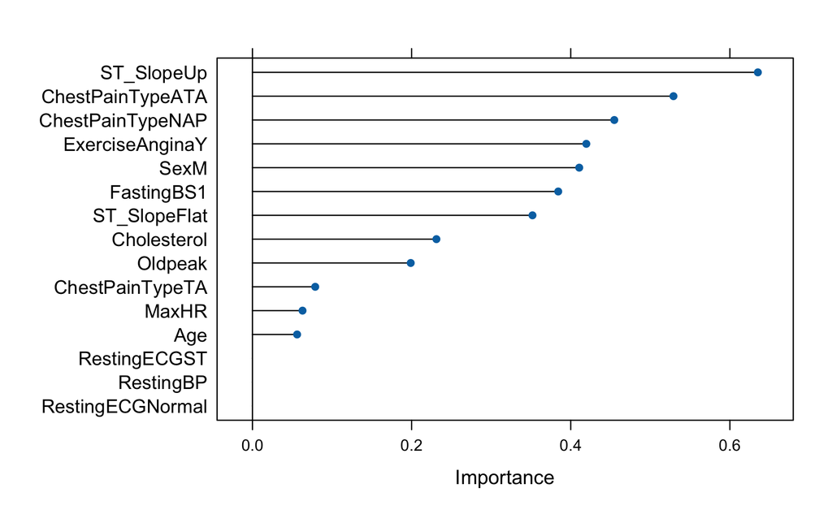

```r
# Compute variable importance using varImp() function
lr_imp <- varImp(lrFit, scale = F)

# Plot the variable importance results
plot(lr_imp, scales = list(y = list(cex = .95)))
```

Using the `varImp()` function and plotting the results, we observe that the variables “RestingECG” and “RestingBP” show no importance. Given this evidence and our earlier observation in the EDA, we decide to exclude these two variables and rerun the model for further refinement.

```r
set.seed(999)
lrFit_upd <- train(HeartDisease ~ Age + Sex + ChestPainType + Cholesterol +  FastingBS + MaxHR + ExerciseAngina + Oldpeak + ST_Slope,
                method = "glmnet",
                family = "binomial",
                data = train_data,
                preProcess = c("center", "scale"),
                tuneGrid = expand.grid(alpha = seq(0, 2, 0.1), lambda = seq(0, .1, 0.01)),
                metric = "Accuracy",
                trControl = ctrl)

prob.test3 <- predict(lrFit_upd, newdata = test_data, type = "prob")

pred.test3 <- as.factor(levels(test_data$HeartDisease)[max.col(prob.test3)])

confusionMatrix(pred.test3, test_data$HeartDisease)
```

```
Confusion Matrix and Statistics

                  Reference
Prediction         No Heart Disease Heart Disease
  No Heart Disease               78           101
  Heart Disease                   0             4

               Accuracy : 0.4481
                 95% CI : (0.3747, 0.5232)
    No Information Rate : 0.5738
    P-Value [Acc > NIR] : 0.9998

                  Kappa : 0.0327

 Mcnemar's Test P-Value : <2e-16

            Sensitivity : 1.0000
            Specificity : 0.0381
         Pos Pred Value : 0.4358
         Neg Pred Value : 1.0000
             Prevalence : 0.4262
         Detection Rate : 0.4262
   Detection Prevalence : 0.9781
      Balanced Accuracy : 0.5190

       'Positive' Class : No Heart Disease
```

The updated model exhibits a slight improvement in accuracy, reaching approximately 44.81%. However, the sensitivity remains at 100%, indicating the model correctly identifies instances without heart disease, while the specificity has increased to 3.81%. This suggests a reduction in false negatives, yet the overall performance remains limited, emphasizing the challenges in predicting heart disease with the given features. Let us try another approach.

**Linear Discriminant Analysis (LDA)**

In the next step we will build a LDA model which is a statistical method utilized for classification and dimensionality reduction, capable of handling multiple classes. Its goal is to find a linear combination of variables that maximizes the separation between different classes while minimizing the variability within each class. LDA assumes normal distribution of features within classes and equal covariance matrices among classes for optimal performance (Hastie, Tibshirani, and Friedman 2009).

The model is built by using the `lda()` function, excluding the variables “RestingBP” and “RestingECG” based on their observed lack of significance during both EDA and initial model training.

```r
# Set seed for reproducibility
set.seed(999)

# Build LDA model
lda_model <- lda(HeartDisease~ Age + Sex + ChestPainType +  Cholesterol +  FastingBS + MaxHR + ExerciseAngina + Oldpeak + ST_Slope, data = train_data)

# Make predictions on the test data
lda_predictions <- predict(lda_model, newdata = test_data, type = "prob")

# Generate a confusion matrix
confusion_matrix <- table(Actual = test_data$HeartDisease, Predicted = lda_predictions$class)
print(confusion_matrix)
```

```
                  Predicted
Actual             No Heart Disease Heart Disease
  No Heart Disease               76             2
  Heart Disease                  72            33
```

```r
# Calculate and print accuracy
accuracy <- sum(diag(confusion_matrix)) / sum(confusion_matrix)
print(paste("Accuracy:", accuracy))
```

```
[1] "Accuracy: 0.595628415300546"
```

Therefore stepwise LDA is employed which approach aims to identify a subset of predictor variables that maximizes the models accuracy. The stepwise LDA process is initiated, utilizing the `stepLDA` method from the `pamr` package.

```r
# Set a seed for reproducibility
set.seed(999)

# Train the stepwise LDA model
ldaFit <- train(HeartDisease ~ Age + Sex + ChestPainType +  Cholesterol +  FastingBS + MaxHR + ExerciseAngina + Oldpeak + ST_Slope,
                method = "stepLDA",
                data = train_data,
                preProcess = c("center", "scale"),
                metric = "Accuracy",
                tuneLength = 10,
                trControl = ctrl)
```

```
correctness rate: 0.81143;  in: "ST_SlopeUp";  variables (1): ST_SlopeUp

 hr.elapsed min.elapsed sec.elapsed
       0.00        0.00        0.35

correctness rate: 0.81262;  in: "ST_SlopeUp";  variables (1): ST_SlopeUp

 hr.elapsed min.elapsed sec.elapsed
      0.000       0.000       0.222

correctness rate: 0.81289;  in: "ST_SlopeUp";  variables (1): ST_SlopeUp

 hr.elapsed min.elapsed sec.elapsed
      0.000       0.000       0.235

correctness rate: 0.81496;  in: "ST_SlopeUp";  variables (1): ST_SlopeUp

 hr.elapsed min.elapsed sec.elapsed
      0.000       0.000       0.227

correctness rate: 0.80213;  in: "ST_SlopeUp";  variables (1): ST_SlopeUp

 hr.elapsed min.elapsed sec.elapsed
      0.000       0.000       0.227

correctness rate: 0.81105;  in: "ST_SlopeUp";  variables (1): ST_SlopeUp

 hr.elapsed min.elapsed sec.elapsed
      0.000       0.000       0.263
```

```r
# Make predictions on the test data
ldaPred <- predict(ldaFit, newdata = test_data)

# Evaluate model performance using confusion matrix
confusionMatrix(ldaPred,test_data$HeartDisease)
```

```
Confusion Matrix and Statistics

                  Reference
Prediction         No Heart Disease Heart Disease
  No Heart Disease               62            16
  Heart Disease                  16            89

               Accuracy : 0.8251
                 95% CI : (0.7622, 0.8772)
    No Information Rate : 0.5738
    P-Value [Acc > NIR] : 3.868e-13

                  Kappa : 0.6425

 Mcnemar's Test P-Value : 1

            Sensitivity : 0.7949
            Specificity : 0.8476
         Pos Pred Value : 0.7949
         Neg Pred Value : 0.8476
             Prevalence : 0.4262
         Detection Rate : 0.3388
   Detection Prevalence : 0.4262
      Balanced Accuracy : 0.8212

       'Positive' Class : No Heart Disease
```

The result shows that the stepwise LDA model achieved an accuracy of approximately 82.51%, exhibiting an improvement over previous models. “ST_Slope” is identified as the key predictor. The confusion matrix shows the model accurately identifies heart disease and no heart disease, with 79.49% sensitivity and 84.76% specificity. The Kappa statistic indicates substantial agreement between predictions and actual outcomes, affirming the models effectiveness.

Now, we want to investigate the variable importance to understand why only one variable was chosen in the stepwise LDA, even though we know from previous analysis that there are multiple good predictors.

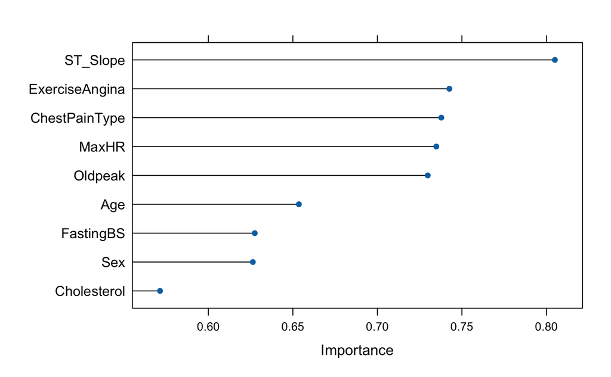

```r
# Compute variable importance using varImp() function
lda_imp <- varImp(ldaFit, scale = F)

# Plot the variable importance results
plot(lda_imp, scales = list(y = list(cex = .95)))
```

The plot reveals that “ST_Slope” is the most important predictor, with an importance score exceeding 0.80. However, other variables like “ExerciseAngina”, “ChestPainType”, “MaxHR”, and “Oldpeak” are also highly important, with scores between 0.7 and 0.75. The decision of stepwise LDA to choose only one variable may be due to high correlation between “ST_Slope” and the other strong predictors, implying that additional variables do not provide much more information. Since “ST_Slope” is categorical, we can not evaluate correlation directly, so we conduct Chi-squared tests for association with the three most important variables.

```r
variables_to_test <- c("ExerciseAngina", "ChestPainType", "MaxHR")

for (variable in variables_to_test) {
  # Create contingency table
  contingency_table <- table(train_data[, variable], train_data[, variable])

  # Perform the Chi-squared test
  chi_square_result <- chisq.test(contingency_table)

  # Print the result of the Chi-squared test
  print(chi_square_result)
}
```

```
    Pearson's Chi-squared test with Yates' continuity correction

data:  contingency_table
X-squared = 730.88, df = 1, p-value < 2.2e-16


    Pearson's Chi-squared test

data:  contingency_table
X-squared = 2205, df = 9, p-value < 2.2e-16


    Pearson's Chi-squared test

data:  contingency_table
X-squared = 83055, df = 12769, p-value < 2.2e-16
```

**Quadratic Discriminant Analysis (QDA)**

This step includes building a QDA model. QDA is a classification technique that extends LDA by relaxing the assumption of equal covariance matrices among classes. While LDA assumes that different classes share a common covariance matrix, QDA allows each class to have its own covariance matrix. This flexibility makes QDA more suitable when the underlying data distributions for different classes have distinct covariances (Hastie, Tibshirani, and Friedman 2009).

The model is built by using the `qda()` function, also excluding the variables “RestingBP” and “RestingECG”. The model is trained on the `train_data` dataset and used to make predictions on the `test_data`. The print output of the model shows details about the model including prior probabilities of groups, group means, and coefficients of quadratic discriminants.

```r
# Set seed for reproducibility
set.seed(999)

# Build QDA model
model_qda <- qda(HeartDisease~ Age + Sex + ChestPainType +  Cholesterol +  FastingBS + MaxHR + ExerciseAngina + Oldpeak + ST_Slope, data = train_data)

# Print the QDA model
print(model_qda)
```

```
Call:
qda(HeartDisease ~ Age + Sex + ChestPainType + Cholesterol +
    FastingBS + MaxHR + ExerciseAngina + Oldpeak + ST_Slope,
    data = train_data)

Prior probabilities of groups:
No Heart Disease    Heart Disease
       0.4517007        0.5482993

Group means:
                        Age      SexM ChestPainTypeATA ChestPainTypeNAP ChestPainTypeTA
No Heart Disease -0.2871973 0.6506024       0.38253012         0.310241      0.06325301
Heart Disease     0.2365992 0.9032258       0.04466501         0.133995      0.04466501
                 Cholesterol FastingBS1      MaxHR ExerciseAnginaY    Oldpeak
No Heart Disease   0.2379187  0.1024096  0.4388667       0.1475904 -0.4365808
Heart Disease     -0.1960025  0.3573201 -0.3615477       0.6327543  0.3596646
                 ST_SlopeFlat ST_SlopeUp
No Heart Disease    0.2018072  0.7680723
Heart Disease       0.7543424  0.1538462
```

```r
# Make predictions on the test data
qda_predictions <- predict(model_qda, newdata = test_data)

# Generate a confusion matrix
confusion_matrix <- table(Actual = test_data$HeartDisease, Predicted = qda_predictions$class)
print(confusion_matrix)
```

```
                  Predicted
Actual             No Heart Disease Heart Disease
  No Heart Disease                0            78
  Heart Disease                   0           105
```

```r
# Calculate and print accuracy
accuracy <- sum(diag(confusion_matrix)) / sum(confusion_matrix)
print(paste("Accuracy:", accuracy))
```

```
[1] "Accuracy: 0.573770491803279"
```

The result shows that the QDA model achieved an accuracy of approximately 57.38%. The confusion matrix indicates that the model predicted all instances as “Heart Disease”, resulting in high sensitivity for heart disease but low overall accuracy. The absence of correct predictions for “No Heart Disease” cases potentially indicates an issue with the models generalization to the data. Considering the limitations and the imbalance in predictions, we will not proceed with further development of this QDA model.

**Naive-Bayes classification**

Now, we build a Naive-Bayes model. Naive-Bayes Classification is a probabilistic machine learning technique based on Bayes Theorem, which describes the probability of an event, given prior knowledge of conditions that might be related to the event. The “naive” aspect comes from the assumption of independence among features, meaning that the presence or absence of one feature does not affect the presence or absence of another, which simplifies the calculation. In a Naive-Bayes Classifier, the goal is to predict the probability of a particular class label given a set of input features (Wasserman 2013).

For creating the model, the function `naiveBayes()` is used. The laplace parameter is set to 1 to handle cases where a particular combination of feature values is not present in the training data. Following the model summary is printed, predictions on the `test_data` are made and the model performance is evaluated by a confusion matrix.

```r
# Set seed for reproducibility
set.seed(999)

# Build naive model
model_naive <- naiveBayes(HeartDisease ~ Age + Sex + ChestPainType +  Cholesterol +  FastingBS + MaxHR + ExerciseAngina + Oldpeak + ST_Slope, data = train_data, laplace = 1)

# Print the QDA model
print(model_naive)
```

```
Naive Bayes Classifier for Discrete Predictors

Call:
naiveBayes.default(x = X, y = Y, laplace = laplace)

A-priori probabilities:
Y
No Heart Disease    Heart Disease
       0.4517007        0.5482993

Conditional probabilities:
                  Age
Y                        [,1]      [,2]
  No Heart Disease -0.2871973 1.0210446
  Heart Disease     0.2365992 0.9182751

                  Sex
Y                           F          M
  No Heart Disease 0.35029940 0.64970060
  Heart Disease    0.09876543 0.90123457

                  ChestPainType
Y                         ASY        ATA        NAP         TA
  No Heart Disease 0.24404762 0.38095238 0.30952381 0.06547619
  Heart Disease    0.77149877 0.04668305 0.13513514 0.04668305

                  Cholesterol
Y                        [,1]      [,2]
  No Heart Disease  0.2379187 0.6942113
  Heart Disease    -0.1960025 1.1592226

                  FastingBS
Y                          0         1
  No Heart Disease 0.8952096 0.1047904
  Heart Disease    0.6419753 0.3580247

                  MaxHR
Y                        [,1]      [,2]
  No Heart Disease  0.4388667 0.9261528
  Heart Disease    -0.3615477 0.9107681

                  ExerciseAngina
Y                          N         Y
  No Heart Disease 0.8502994 0.1497006
  Heart Disease    0.3679012 0.6320988

                  Oldpeak
Y                        [,1]      [,2]
  No Heart Disease -0.4365808 0.6644533
  Heart Disease     0.3596646 1.0840917

                  ST_Slope
Y                        Down       Flat         Up
  No Heart Disease 0.03283582 0.20298507 0.76417910
  Heart Disease    0.09359606 0.75123153 0.15517241
```

```r
# Make predictions on the test data
predmodel.naive <- predict(model_naive, newdata = test_data)

# Evaluate model performance using confusion matrix
confusionMatrix(predmodel.naive, test_data$HeartDisease)
```

```
Confusion Matrix and Statistics

                  Reference
Prediction         No Heart Disease Heart Disease
  No Heart Disease               53            10
  Heart Disease                  25            95

               Accuracy : 0.8087
                 95% CI : (0.7442, 0.863)
    No Information Rate : 0.5738
    P-Value [Acc > NIR] : 1.426e-11

                  Kappa : 0.5991

 Mcnemar's Test P-Value : 0.01796

            Sensitivity : 0.6795
            Specificity : 0.9048
         Pos Pred Value : 0.8413
         Neg Pred Value : 0.7917
             Prevalence : 0.4262
         Detection Rate : 0.2896
   Detection Prevalence : 0.3443
      Balanced Accuracy : 0.7921

       'Positive' Class : No Heart Disease
```

The outcome shows the predicted probabilities of heart disease based on various features. The accuracy of the model is approximately 80.87%, with a sensitivity of 67.95% and specificity of 90.48%. This suggests that the model performs well in identifying both positive and negative cases. The Kappa statistic indicates substantial agreement between predicted and observed outcomes. The balanced accuracy is 79.21%, reinforcing the overall effectiveness of the Naive Bayes Classifier.

This models accuracy closely matches the LDA model, demonstrating good sensitivity and specificity. However, the LDA model slightly outperforms it overall. To enhance decision-making, we will conduct a thorough analysis of errors and refine the models accordingly.

**Errors with training and testing sets**

In this analysis, we evaluate the performance of the two best models, LDA and Naive Bayes models, using repeated random sub-sampling. The process involves the following steps:

- Sampling: Randomly select 80% of the dataset for training, leaving the remaining 20% for testing,
- Training Models: Build LDA and Naive Bayes models using the selected variables and the training subset,
- Prediction: Make predictions on the testing subset using both models,
- Evaluation: Assess the models performance by calculating the testing error for both LDA and Naive Bayes.

The entire process is repeated 100 times to obtain a robust estimate of the testing error. The boxplot visualizes the distribution of testing errors for each model.

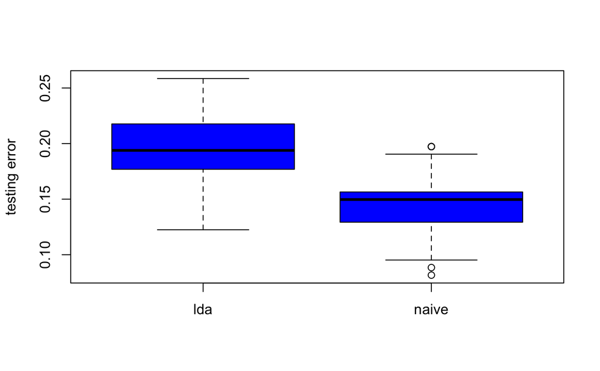

```r
# Set seed for reproducibility
set.seed(999)

# Create error output matrix
err.out <- matrix(NA, nrow = 100, ncol = 2)

for (i in 1:100) {
  train <- sample(1:nrow(train_data), nrow(train_data) * 0.8)  # 80% of the sample for training
  n.test <- nrow(train_data) * 0.2

  # Train
  lda.class <- lda(HeartDisease ~ ST_Slope, data = train_data[train, ])
  naive.class <- naiveBayes(HeartDisease ~ Age + Sex + ChestPainType +  Cholesterol +  FastingBS + MaxHR + ExerciseAngina + Oldpeak + ST_Slope, data = train_data[train, ])

  # Predict
  pred.lda <- predict(lda.class, newdata = train_data[-train, ])$class
  pred.naive <- predict(naive.class, newdata = train_data[-train, ])

  # Test
  ConfMat.lda <- confusionMatrix(pred.lda, train_data$HeartDisease[-train])
  err.lda <- 1 - ConfMat.lda$overall["Accuracy"]

  ConfMat.naive <- confusionMatrix(pred.naive, train_data$HeartDisease[-train])
  err.naive <- 1 - ConfMat.naive$overall["Accuracy"]

  err.out[i, 1] <- err.lda
  err.out[i, 2] <- err.naive
}

boxplot(err.out,col="blue",xlab="", ylab="testing error", names=c("lda", "naive"))
```

The distribution of errors, as shown in the boxplot, indicates that the LDA model has a higher variability in its testing errors compared to the Naive Bayes model. Although the accuracy of LDA might be slightly better, the higher variability suggests that its performance is less consistent across different samples.

The below calculated mean testing error rates for the LDA and Naive Bayes models are 19.51% and 14.54%, respectively. Despite the slightly higher overall mean error for the LDA model, the Naive Bayes model demonstrates a more consistent and lower average testing error across different samples.

```r
# Calculate mean testing error rates
apply(err.out,2,mean)
```

```
[1] 0.1951020 0.1454422
```

When deciding to choose the Naive Bayes model as final model, despite its slightly lower accuracy, several factors need to be considered. One crucial aspect is the nature of the errors made by each model. In the confusion matrix analysis, it is observed that the Naive Bayes model tends to make more false positive errors, predicting more instances as Heart Disease when they are not. This characteristic might be advantageous in certain scenarios, especially if the consequences of missing a true positive (failing to predict an actual Heart Disease case) are considered more severe than the consequences of having some false positives. Additionally, the fact that the Naive Bayes model has a higher number of wrong predictions with Heart Disease, as opposed to LDA, indicates a certain robustness in its ability to detect cases with Heart Disease. This robustness could be valuable in real-world applications where correctly identifying positive cases is a priority. Finally, the decision to proceed with the Naive Bayes model considers not only accuracy but also the nature of errors and specific application requirements.

# Incorporing life impact

In this analysis, we explore the incorporation of life impact into model predictions, specifically focusing on the importance of True Positives in predicting Heart Disease. The table below represents the adjusted impact table reflecting the priority of correctly identifying cases of Heart Disease:

| Prediction/Reference | No Heart Disease | Heart Disease |
| --- | --- | --- |
| No Heart Disease | 0 | 0 |
| Heart Disease | -1 | 2 |

The adjusted impact table assigns values to different outcomes, indicating the importance of correct and incorrect predictions, with a higher emphasis on correctly predicting cases of Heart Disease.

To determine the optimal threshold for giving a “Heart Disease” prediction, we conducted a hyper-parameter selection analysis. We use the final Naive Bayes classifier trained on various threshold values and evaluate its performance across 50 replicates. The boxplot summarizes the impact of True Positives and False Positives at different thresholds.

```r
# Set seed for reproducibility
set.seed(999)

# Adjusted impact table as a vector reflecting the importance of TP
impact.unit <- c(0, -1, 0, 2)

# Selecting the optimal threshold
impact.i <- matrix(NA, nrow = 50, ncol = 10)

# Loop over different threshold values
j <- 0
for (threshold in seq(0.05, 0.5, 0.05)) {
  j <- j + 1
  cat(j)

  # Loop over 50 replicates
  for (i in 1:50) {
    # Partition data into training (40%) and testing sets (60%)
    d <- createDataPartition(train_data$HeartDisease, p = 0.4, list = FALSE)

    # Select training sample
    train <- train_data[d,]
    test <- train_data[-d,]

    # Consider the Naive Bayes classifier
    full.model <- naiveBayes(HeartDisease ~ Age + Sex + ChestPainType +  Cholesterol +  FastingBS + MaxHR + ExerciseAngina + Oldpeak + ST_Slope, data = train)

    # Class probabilities
    probability <- as.data.frame(predict(full.model, test, type = "raw"))

    # Predictions with a given threshold
    HD.pred <- rep("No Heart Disease", nrow(test))
    HD.pred[which(probability[, "Heart Disease"] > threshold)] <- "Heart Disease"

    # Confusion Matrix
    CM <- confusionMatrix(factor(HD.pred), test$HeartDisease)$table

    # Calculate impact per applicant with adjusted impact unit
    impact.applicant <- sum(impact.unit * CM) / sum(CM)
    impact.i[i, j] <- impact.applicant
  }
}
```

```
12345678910
```

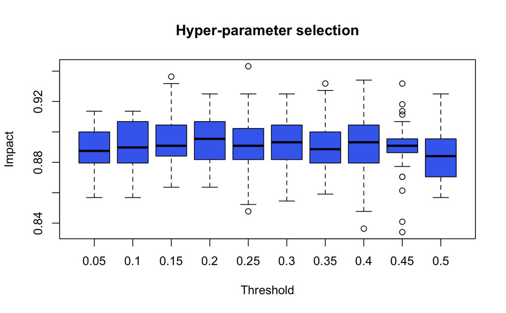

```r
# Summary of impact value of predictions
boxplot(impact.i, main = "Hyper-parameter selection",
        ylab = "Impact",
        xlab = "Threshold", names = seq(0.05, 0.5, 0.05), col = "royalblue2")
```

```r
# Calculate median of thresholds
apply(impact.i, 2, median)
```

```
 [1] 0.8875000 0.8897727 0.8909091 0.8954545 0.8909091 0.8931818 0.8886364 0.8931818
 [9] 0.8909091 0.8840909
```

**Final Prediction**

In the final step, we utilize the completed Naive-Bayes Model to make predictions on the dataset, taking into account the selected threshold of 0.2. This threshold determines the classification of instances as either “Heart Disease” or “No Heart Disease”. The ensuing evaluation involves a confusion matrix to assess the accuracy of these predictions.

```r
# Set seed for reproducibility
set.seed(999)

# Build the Naive Bayes model on the training data
final_model_naive <- naiveBayes(HeartDisease ~ Age + Sex + ChestPainType +  Cholesterol +  FastingBS + MaxHR + ExerciseAngina + Oldpeak + ST_Slope, data = train_data)

# Predict probabilities on the test data
probability <- as.data.frame(predict(final_model_naive, newdata = test_data, type = "raw"))

# Set the chosen threshold for predicting Heart Disease
threshold <- 0.2

# Apply the threshold to make predictions
Heart.pred <- rep("No Heart Disease", nrow(test_data))
Heart.pred[which(probability[,"Heart Disease"] > threshold)] = "Heart Disease"

# Confusion matrix for the predictions
confusionMatrix(factor(Heart.pred), test_data$HeartDisease)$table
```

```
                  Reference
Prediction         No Heart Disease Heart Disease
  No Heart Disease               51             9
  Heart Disease                  27            96
```

Comparing the evaluation of the final model with the threshold to the initial naive Bayes model, we observe an increase of 3 predictions for Heart Disease. This results in two false positives, but importantly, one additional true positive, indicating the ability to detect one more case of heart disease by incorporating the threshold. Despite a slightly lower accuracy, the emphasis on prioritizing heart disease cases is evident, aligning with the intended goal.

# Conclusion

In conclusion, this report embarked on the exploration of heart disease prediction using a Naive Bayes classifier. We began by conducting exploratory data analysis and preprocessing to gain insights into the dataset. The subsequent development of various models lead to choose the Naive Bayes model. Despite a slightly lower overall accuracy compared to an alternative LDA model, was justified by considering the specific nature of errors and robustness exhibited by the Naive Bayes approach. The model was further fine-tuned by incorporating the impact of prediction thresholds, aiming to prioritize the importance of correctly identifying true positive cases. The final Naive Bayes model, with an optimized threshold of 0.2, demonstrated promising predictive capabilities, showcasing its potential for effective heart disease prediction.

# References

Association, American Heart. 2023. “Understanding Blood Pressure Readings.” https://www.heart.org/en/health-topics/high-blood-pressure/understanding-blood-pressure-readings.

Clinic, Cleveland. 2022. “Cholesterol Numbers and What They Mean.” https://my.clevelandclinic.org/health/articles/11920-cholesterol-numbers-what-do-they-mean.

Disease Control, Centers for, and Prevention. 2022. “Target Heart Rate and Estimated Maximum Heart Rate.” https://www.cdc.gov/physicalactivity/basics/measuring/heartrate.htm#:~:text=To%20estimate%20your%20maximum%20age,beats%20per%20minute%20(bpm).

Hastie, Trevor, Robert Tibshirani, and Jerome Friedman. 2009. *The Elements of Statistical Learning*. 2nd ed. Springer Series in Statistics. Springer New York, NY.

James, Gareth, Daniela Witten, Trevor Hastie, and Robert Tibshirani. 2013. *An Introduction to Statistical Learning*. Springer Texts in Statistics 1. Springer New York, NY.

Kharel, Himal, Nishan B Pokhrel, Biraj Pokhrel, Parikshit Chapagain, and Chandra M. Poudel. 2020. “Implications of Localized ST Depression in a Vascular Territory and Altered Precordial t-Wave Balance in Ischemic Heart Disease.” https://www.ncbi.nlm.nih.gov/pmc/articles/PMC7359984/.

Organization, World Health. 2021. “Cardiovascular Diseases (CVDs).” https://www.who.int/news-room/fact-sheets/detail/cardiovascular-diseases-(cvds).

Wasserman, Larry. 2013. *All of Statistics*. Springer Texts in Statistics 1. Springer New York, NY.